# Hacker Club

Use technology to enrich your life.

[figure not shown]

## Agenda

- A few examples. Don't worry about understanding the code.
- Introduction to the tools
  - conda by continuum.io
  - Jupyter
- Python basics
- Notebook source

# Before we begin...

This is a cell:

```python
"Hello World!"
```

```
'Hello World!'
```

Cells contain code. There is cell input and cell output. When you see a cell, just know that it is Python code.

# Housing Market

I recently moved. I knew selling my house in Enfield would be difficult. During this time, I wrote a python script to continually save data on the housing market in the upper valley. I have been continually adding to this dataset since.

Below, I will show you a few trivial examples exploring this dataset using python.

### First rule in programming: Be lazy. Use other people's code. Don't re-invent the wheel.

The point of the first example is to show you what is possible when using very little code.

Below, we use a module called pandas written by somebody else to help us aggregate and plot our housing market dataset.

```python
import pandas
```

## Next, we load our data into python

Here we store the data in a variable called `df`.

`df` is a DataFrame.

```python
df = pandas.read_pickle('../uppervalleyhousingmarket.pickle')
```

## What's a DataFrame?

You can think of a DataFrame as an excel sheet with rows and columns.

```python
df.head()
```

|  | _updated | acres | address | baths | beds | built | contract | days_on_market | delta | id | ... | price_low | property_type | sale_date | sale_price | short_address | sold | sold_by | sqft | town | updated |
| --- | --- | --- | --- | --- | --- | --- | --- | --- | --- | --- | --- | --- | --- | --- | --- | --- | --- | --- | --- | --- | --- |
| 0 | 2015-05-20 19:57:40.033336 | 0.51 | 217 Main Street Enfield, NH 03748 | 1 | 3 | None | True | 30 | -9900 | 1 | ... | 304900 | Residential | 2013-05-10 | 295000 | 217 Main St | True | Christine Michalenoick | 2091 | Enfield | 2013-05-10 18:08:40 |
| 1 | 2015-05-20 19:57:40.085213 | 3.08 | 31 Alfano Drive Enfield, NH 03748 | 2 | 3 | None | True | 321 | -19900 | 2 | ... | 204900 | Residential | 2013-05-16 | 185000 | 31 Alfano Dr | True | Jack OSullivan,ABR | 1880 | Enfield | 2013-05-16 13:46:39 |
| 2 | 2015-09-15 10:15:43.376529 | 0.60 | 66 May Enfield, NH 03748 | 1 | 2 | None | True | 217 | 0 | 3 | ... | 64900 | Residential | 2013-06-04 | 64900 | 66 May | True | Melinda Johnston | 708 | Enfield | 2013-06-06 07:09:53 |
| 3 | 2015-09-15 10:15:44.951620 | 0.72 | 34 NH ROUTE 4A Enfield, NH 03748 | 2 | 3 | None | True | 59 | 200 | 4 | ... | 89000 | Residential | 2013-06-07 | 89200 | 34 Nh Route 4A | True | Christine Michalenoick | 1335 | Enfield | 2013-06-07 14:57:12 |
| 4 | 2015-09-15 10:16:41.008195 | 7.10 | 185 Poverty Lane Lebanon, NH 03766 | 2 | 3 | None | True | 201 | 0 | 5 | ... | 210000 | Residential | 2013-06-26 | 210000 | 185 Povertyln | True | Sandra Dell | 1977 | Lebanon | 2013-06-30 06:12:51 |

5 rows × 30 columns

## About DataFrames

The shape attribute tells us how many rows and columns there are. In this dataset, we have 30 attributes describing 1,679 listings in the upper valley.

```python
df.shape
```

```
(1679, 30)
```

The columns attribute tell us the column names.

```python
df.columns
```

```
Index([            u'_updated',                u'acres',
                    u'address',                u'baths',
                       u'beds',                u'built',
                   u'contract',       u'days_on_market',
                      u'delta',                   u'id',
                    u'img_url',                  u'lat',
                       u'link',               u'listed',
                  u'listed_by',                  u'lon',
                        u'mls', u'predicted_sale_price',
                      u'price',           u'price_high',
                  u'price_low',        u'property_type',
                  u'sale_date',           u'sale_price',
              u'short_address',                 u'sold',
                    u'sold_by',                 u'sqft',
                       u'town',              u'updated'],
      dtype='object')
```

## DataFrames can be filtered

Here we select only properties in Grantham:

```python
df[df['town'] == 'Grantham'].head()
```

|  | _updated | acres | address | baths | beds | built | contract | days_on_market | delta | id | ... | price_low | property_type | sale_date | sale_price | short_address | sold | sold_by | sqft | town | updated |
| --- | --- | --- | --- | --- | --- | --- | --- | --- | --- | --- | --- | --- | --- | --- | --- | --- | --- | --- | --- | --- | --- |
| 466 | 2015-05-24 10:07:51.506913 | 0.70 | 1 Fairway Grantham, NH 03753 | 2 | 3 | None | True | 119 | -5900 | 467 | ... | 81900 | Residential | 2013-12-06 | 76000 | 1 Fairway | True |  | 2370 | Grantham | 2014-03-18 15:56:23 |
| 467 | 2015-05-24 10:07:51.560277 | 1.87 | 31 Clearwater Drive Grantham, NH 03753 | 3 | 3 | None | True | 62 | -9900 | 468 | ... | 264900 | Residential | 2014-02-10 | 255000 | 31 Clearwater Dr | True | Dick DuMez | 2874 | Grantham | 2014-03-18 15:56:23 |
| 468 | 2015-05-24 10:07:51.607793 | 1.00 | 13 Forest Road Grantham, NH 03753 | 3 | 3 | None | True | 194 | -7900 | 469 | ... | 189900 | Residential | 2015-02-24 | 182000 | 13 Forest Rd | True | Linda Johnson | 2456 | Grantham | 2015-02-26 11:04:12 |
| 469 | 2015-05-24 10:07:51.656985 | 5.11 | 178 Meadow Brook Rd Grantham, NH 03753 | 3 | 4 | None | True | 102 | 6600 | 470 | ... | 229900 | Residential | 2015-03-27 | 236500 | 178 Meadow Brook Rd | True | Derek Cosentino | 3000 | Grantham | 2015-03-27 17:32:15 |
| 470 | 2015-05-24 10:07:52.040430 | 0.00 | 647 Marmot Lane 47 Grantham, NH 03753 | 3 | 3 | None | True | 259 | -9000 | 471 | ... | 80000 | Condo | 2013-09-27 | 71000 | 647 Marmotln 47 | True | Susan Latham | 1624 | Grantham | 2014-03-18 15:56:23 |

5 rows × 30 columns

## DataFrames can be plotted

Let's plot days on the market by town.

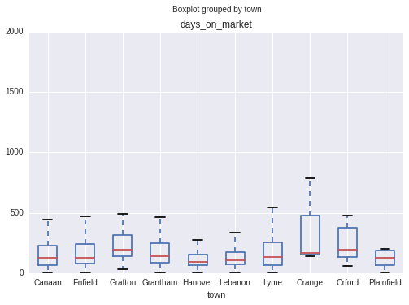

```python
df.boxplot(by='town', column=['days_on_market'])
```

## Selling my house

Getting back to selling my house in Enfield. Who should I list with? Let's look at the top 10 listing agents in Enfield.

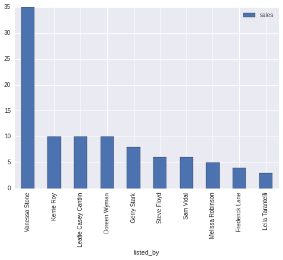

```python
df[(df['town']=='Enfield') & (df['sold'])].groupby('listed_by').count()[['id']].rename(columns={'id':'sales'}).sort('sales', ascending=0).head(10).plot(kind='bar')
```

## Predicting Sale Price

The dataset includes a predicted sale price which is a simple linear regression using the 30 available attributes.

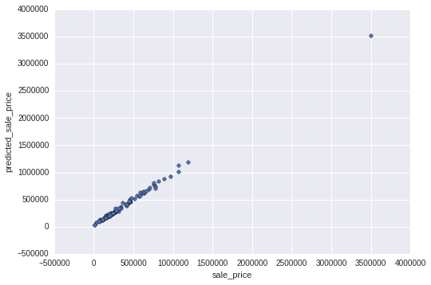

```python
df[(df['predicted_sale_price'] > 0) & (df['sold'])].plot(kind='scatter', x='sale_price', y='predicted_sale_price')
```

### Where do we go from here?

If people are interested in this dataset, I can show how to:

- Use the scikit-learn module to predict sale prices
- Set up a twitter bot to automatically tweet when:
  - There are new listings
  - Prices change
  - Properties go under contracts
  - Sales

### [@PeoplesHouses](https://twitter.com/PeoplesHouses)

```python
%%html
<blockquote class="twitter-tweet" lang="en"><p lang="en" dir="ltr">Sold! 29 Rope Ferry Rd <a href="https://twitter.com/hashtag/HanoverNH?src=hash">#HanoverNH</a> sold for $3,500,000. Asked $3,795,000. Predicted $3,514,000 <a href="http://t.co/k5PheTcjhJ">pic.twitter.com/k5PheTcjhJ</a></p>&mdash; All People&#39;s Houses (@PeoplesHouses) <a href="https://twitter.com/PeoplesHouses/status/626490947388481536">July 29, 2015</a></blockquote>
<script async src="//platform.twitter.com/widgets.js" charset="utf-8"></script>
```

> Sold! 29 Rope Ferry Rd [#HanoverNH](https://twitter.com/hashtag/HanoverNH?src=hash) sold for $3,500,000. Asked $3,795,000. Predicted $3,514,000 [pic.twitter.com/k5PheTcjhJ](http://t.co/k5PheTcjhJ)

> — All People's Houses (@PeoplesHouses) [July 29, 2015](https://twitter.com/PeoplesHouses/status/626490947388481536)

## Name Explorer

One of the best ways to learn python is to experiement with a dataset. The SSA's name dataset is perfect for this. Below, we will use this dataset to plot name popularity.

The point of this example is to show how to explore a publicly available dataset using python.

### Loading the data

The data comes separated by year. Below is the code to assemble the dataset into male and female DataFrames.

> Note: this process could easily be done in Excel or another program.

```python
import glob
years = []
for path in glob.glob('names/*.txt'):
    year = pandas.to_datetime(path[9:-4], format='%Y')
    df = pandas.read_csv(path, names=['name','sex','c'])
    df['year'] = year
    years.append(df)
df = pandas.concat(years)
df['date'] = pandas.DatetimeIndex(df.year)
del df['year']
female = df[df['sex']=='F'].groupby(['name', 'date']).sum().unstack(level=0)
male = df[df['sex']=='M'].groupby(['name', 'date']).sum().unstack(level=0)
female.columns = female.columns.droplevel()
male.columns = male.columns.droplevel()
```

### Top Male Names of 1980

The year I was born.

```python
df[((df['sex']=='M')) & (df['date'] == '1980-01-01')].sort(['date','c'], ascending=[0,0]).head()
```

|  | name | sex | c | date |
| --- | --- | --- | --- | --- |
| 12157 | Michael | M | 68666 | 1980-01-01 |
| 12158 | Christopher | M | 49086 | 1980-01-01 |
| 12159 | Jason | M | 48176 | 1980-01-01 |
| 12160 | David | M | 41913 | 1980-01-01 |
| 12161 | James | M | 39312 | 1980-01-01 |

### Top Female Names of 2012

The year Audrey was born.

```python
df[(df['sex']=='F') & (df['date'] == '2012-01-01')].sort(['date','c'], ascending=[0,0]).head()
```

|  | name | sex | c | date |
| --- | --- | --- | --- | --- |
| 0 | Sophia | F | 22267 | 2012-01-01 |
| 1 | Emma | F | 20902 | 2012-01-01 |
| 2 | Isabella | F | 19058 | 2012-01-01 |
| 3 | Olivia | F | 17277 | 2012-01-01 |
| 4 | Ava | F | 15512 | 2012-01-01 |

### I have clearly peaked

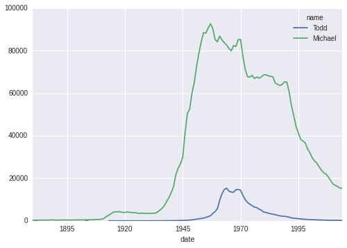

```python
male[['Todd', 'Michael']].plot(kind='line')
```

### Audrey is making a come back

Anyone have any names they want me to try?

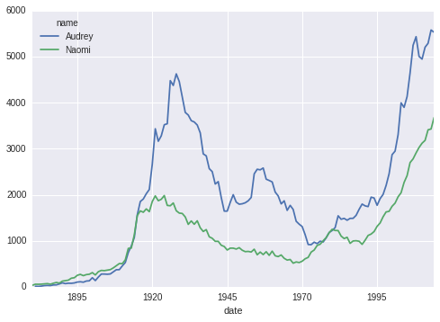

```python
female[['Audrey', 'Naomi']].plot(kind='line')
```

### How many spelling variations of Jayden there are?

Metaphone (and Double Metaphone) are popular algorithms for phonetic hashing. It's a good algorithm to find similar sounding words when spoken in English.

As is usually the case, someone already implemented this algorithm in python for us.

Let's import it and initialize.

```python
from fuzzy import DMetaphone
dmetaphone = DMetaphone()
```

Next, let's populate a lookup table using the Double Metaphone hash of each male name

```python
from collections import defaultdict
phonetic_dict = defaultdict(set)
```

```python
for name in set(df[(df['sex']=='M')]['name']):
    hash1, hash2 = dmetaphone(name)
    if hash1:
        phonetic_dict[hash1].add(name)
    if hash2:
        phonetic_dict[hash1].add(name)
```

We have our lookup table. Let's try to seach for names that sound like Jayden.

```python
dmetaphone('Jayden')
```

```
['JTN', 'ATN']
```

```python
phonetic_dict['JTN']
```

```
{'Geatano',
 'Gedeon',
 'Giddeon',
 'Gideon',
 'Jaaden',
 'Jadaan',
 'Jadan',
 'Jaddan',
 'Jadden',
 'Jadean',
 'Jadeen',
 'Jadein',
 'Jaden',
 'Jadenn',
 'Jadeon',
 'Jadeyn',
 'Jadian',
 'Jadien',
 'Jadin',
 'Jadn',
 'Jadon',
 'Jadyen',
 'Jadyn',
 'Jadyne',
 'Jadynn',
 'Jaedan',
 'Jaeden',
 'Jaedin',
 'Jaedon',
 'Jaedyn',
 'Jaedynn',
 'Jaetyn',
 'Jahden',
 'Jahdon',
 'Jaidan',
 'Jaidden',
 'Jaiden',
 'Jaidenn',
 'Jaidin',
 'Jaidn',
```

[output cut: 49 more lines]

```
 'Jeydon',
 'Jhaden',
 'Jhaiden',
 'Jhayden',
 'Jiten',
 'Jodan',
 'Joden',
 'Joedon',
 'Joyden',
 'Juden',
 'Judon',
 'Jutin',
 'Jyden',
 'Zhaiden',
 'Zhayden'}
```

# Deep Dreaming with Neural Networks

Again, following the first rule of programming, I am using someone else code. This code is from data scientists at google. They have a trained neural network (model) of classified images. This simply means, they showed an algorithm a picture of a duck and told it it was a duck. The network then analyzed the picture and it *learns* what a duck is.

The point of this example is show you something interesting that you can do with relatively little effort.

Google wanted a way to visualize what was happening in their neural networks. They highlighted features in images that each layer in their network *saw*. In their [blogpost](http://googleresearch.blogspot.com/2015/06/inceptionism-going-deeper-into-neural.html), they showed a few very cool looking images.

[figure not shown]

### Google provided a jupyter notebook to be able to create your own deep dream images

I copy and pasted it into my notebook and annotated it below.

### Reminder: Don't worry about the code. It's from somebody else.

First, they import all of the libraries that are used.

```python
# imports and basic notebook setup
from cStringIO import StringIO
import os
import shutil
import numpy as np
import scipy.ndimage as nd
import PIL.Image
from IPython.display import clear_output, Image, display
from google.protobuf import text_format

import caffe

def showarray(a, fmt='jpeg'):
    a = np.uint8(np.clip(a, 0, 255))
    f = StringIO()
    PIL.Image.fromarray(a).save(f, fmt)
    display(Image(data=f.getvalue()))
```

Next, they prepare the network and add a wrapper for converting to and from Caffe. [Caffe](http://caffe.berkeleyvision.org/) is a deep learning framework from berkeley.

```python
model_path = '/home/boland/Software/caffe/models/bvlc_googlenet/' # substitute your path here
net_fn   = model_path + 'deploy.prototxt'
param_fn = model_path + 'bvlc_googlenet.caffemodel'

# Patching model to be able to compute gradients.
# Note that you can also manually add "force_backward: true" line to "deploy.prototxt".
model = caffe.io.caffe_pb2.NetParameter()
text_format.Merge(open(net_fn).read(), model)
model.force_backward = True
open('tmp.prototxt', 'w').write(str(model))

net = caffe.Classifier('tmp.prototxt', param_fn,
                       mean = np.float32([104.0, 116.0, 122.0]), # ImageNet mean, training set dependent
                       channel_swap = (2,1,0)) # the reference model has channels in BGR order instead of RGB

# a couple of utility functions for converting to and from Caffe's input image layout
def preprocess(net, img):
    return np.float32(np.rollaxis(img, 2)[::-1]) - net.transformer.mean['data']
def deprocess(net, img):
    return np.dstack((img + net.transformer.mean['data'])[::-1])
```

Next, a function is defined that highlights the feature the network has seen.

```python
def make_step(net, step_size=1.5, end='inception_4c/output', jitter=32, clip=True):
    '''Basic gradient ascent step.'''

    src = net.blobs['data'] # input image is stored in Net's 'data' blob
    dst = net.blobs[end]

    ox, oy = np.random.randint(-jitter, jitter+1, 2)
    src.data[0] = np.roll(np.roll(src.data[0], ox, -1), oy, -2) # apply jitter shift

    net.forward(end=end)
    dst.diff[:] = dst.data  # specify the optimization objective
    net.backward(start=end)
    g = src.diff[0]
    # apply normalized ascent step to the input image
    src.data[:] += step_size/np.abs(g).mean() * g

    src.data[0] = np.roll(np.roll(src.data[0], -ox, -1), -oy, -2) # unshift image

    if clip:
        bias = net.transformer.mean['data']
        src.data[:] = np.clip(src.data, -bias, 255-bias)
```

Here, they provide a function to visualize what the network is *seeing*.

```python
def deepdream(net, base_img, iter_n=10, octave_n=4, octave_scale=1.4, end='inception_4c/output', clip=True, **step_params):
    # prepare base images for all octaves
    octaves = [preprocess(net, base_img)]
    for i in xrange(octave_n-1):
        octaves.append(nd.zoom(octaves[-1], (1, 1.0/octave_scale,1.0/octave_scale), order=1))

    src = net.blobs['data']
    detail = np.zeros_like(octaves[-1]) # allocate image for network-produced details
    for octave, octave_base in enumerate(octaves[::-1]):
        h, w = octave_base.shape[-2:]
        if octave > 0:
            # upscale details from the previous octave
            h1, w1 = detail.shape[-2:]
            detail = nd.zoom(detail, (1, 1.0*h/h1,1.0*w/w1), order=1)

        src.reshape(1,3,h,w) # resize the network's input image size
        src.data[0] = octave_base+detail
        for i in xrange(iter_n):
            make_step(net, end=end, clip=clip, **step_params)

            # visualization
            vis = deprocess(net, src.data[0])
            if not clip: # adjust image contrast if clipping is disabled
                vis = vis*(255.0/np.percentile(vis, 99.98))
            showarray(vis)
            print octave, i, end, vis.shape
            clear_output(wait=True)

        # extract details produced on the current octave
        detail = src.data[0]-octave_base
    # returning the resulting image
    return deprocess(net, src.data[0])
```

## Our Code

```python
# Define a function to produce multiple frames.
def trip(frame, end='inception_4c/output', frames=10):
    h, w = frame.shape[:2]
    s = 0.05 # scale coefficient
    for i in xrange(frames):
        frame = deepdream(net, frame, end=end)

        # Zoom and rotate by just a tad.
        frame = nd.affine_transform(frame, [1-s, 1-s, 1], [h*s/2, w*s/2, 0], order=1)
```

Let's load one of our own images.

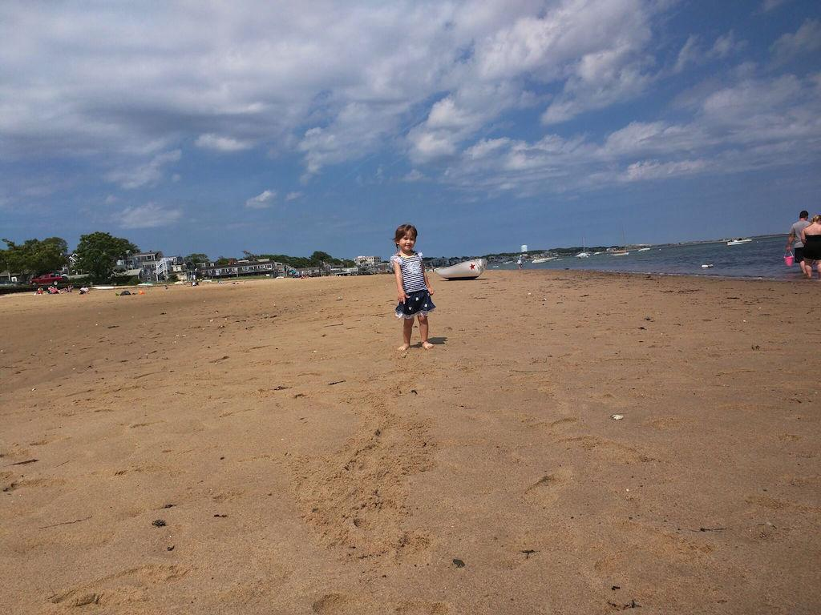

```python
# Import audrey
img = np.float32(PIL.Image.open('../audreysm.jpg'))
showarray(img)
```

What happens when you send audrey through Google's deep dreaming neural network?

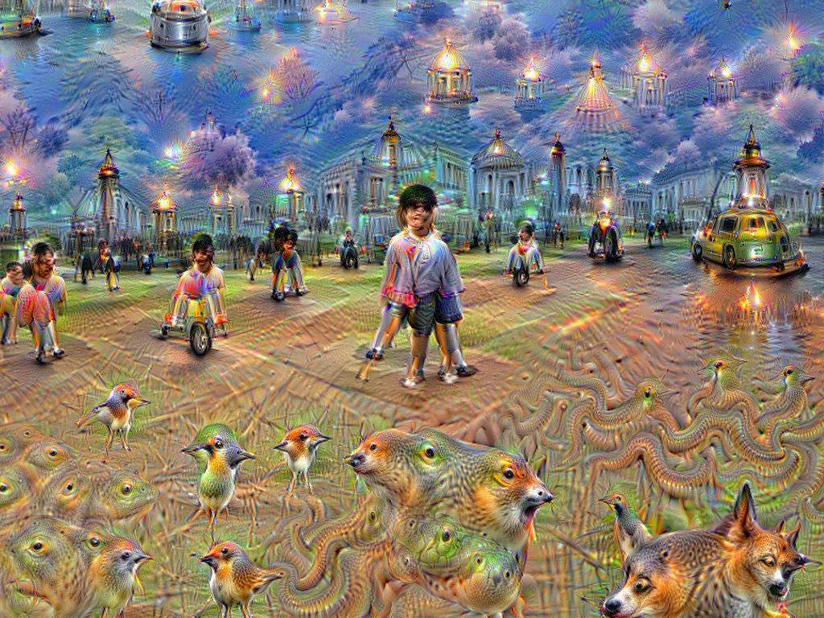

```
3 9 inception_4c/output (768, 1024, 3)
```

```python
trip(img)
```

### What happens when we send Adimab a few hundred iterations into dreamland?

[figure not shown]

# Installing Python

Python can be installed on virtually any computer. I recommend using the python distribution called Anaconda from continuum.io. It is available for Windows, Mac and Linux. Set up is easy but takes a little while.

1. Download Anaconda from Continuum.io or from the shared drive (S:\0.Shared\Software\Anaconda)
2. Install Anaconda by double clicking the installer

> I would recommend product engineering install jupyter by running `pip install jupyter`

## Running Python

There are dozens of ways to run python code. I recommend using a python notebook called Jupyter.

> Note: Jupyter is the new name for IPython notebook

After Anaconda is installed, from the Start menu, select IPython Notebook.

> Note: Project engineering should run `jupyter notebook`.

If everything worked, you should see a screen similar to this

[figure not shown]

### Creating your first notebook

From the New menu, under Notebooks, choose Python 2.

[figure not shown]

## Python Basics

I can only scratch the surface today. If there is interest, I can go deeper in a future meeting.

- Numbers
- Strings
- Lists
- and More!

### Let's use python as a calculator

Please feel free to follow along.

```python
5 + 5
```

```
10
```

```python
5 * 5
```

```
25
```

```python
5 + (2 * 40)
```

```
85
```

```python
1 / 4
```

```
0
```

Wat.

```python
from IPython.display import Audio
Audio(url='Record Scratch.mp3', autoplay=True)
```

[interactive chart not shown]

### What happened?

Expecting a decimal? Use a decimal. In python, these are called floats.

```python
1 / 4.0
```

```
0.25
```

The type function will tell you the type of a variable.

```python
type(1)
```

```
int
```

```python
type(4.0)
```

```
float
```

Integers are whole numbers floats are fractions.

### Playing with strings

```python
'Hello World!'
```

```
'Hello World!'
```

```python
'Hello' + ' ' + 'World!'
```

```
'Hello World!'
```

```python
greeting = 'Hello World'
```

```python
# String slicing
greeting[0:5]
```

```
'Hello'
```

```python
greeting[6:]
```

```
'World'
```

### Lists

```python
[1, 2, 3, 4]
```

```
[1, 2, 3, 4]
```

```python
numbers = [1, 2, 3, 4]
```

```python
# List slicing works the same way as string slicing
numbers[0:2]
```

```
[1, 2]
```

### Dictionaries

```python
{'name': 'Todd', 'age': 34}
```

```
{'age': 34, 'name': 'Todd'}
```

```python
person = {
    'name': 'Todd Boland',
    'age': 34
}
```

```python
person['name']
```

```
'Todd Boland'
```

```python
person['age']
```

```
34
```

```python
# String slicing works as expected
person['name'][5:]
```

```
'Boland'
```

### Control flow

If statements and loops are your main tools for control flow in python.

```python
person
```

```
{'age': 34, 'name': 'Todd Boland'}
```

```python
if person['age'] > 25:
    print 'Adult'
elif person['age'] > 18:
    print 'young adult'
else:
    print 'Child'
```

```
Adult
```

```python
numbers
```

```
[1, 2, 3, 4]
```

```python
for item in numbers:
    print item
```

```
1
2
3
4
```

## Let's make a tip calculator

Believe it or not, there was a time you could have made some money with this on the App Store.

The meal comes to $46.90. Tax is 11% and we want to tip 15%.

First step is to assign the cost of the meal to a variable.

```python
meal = 46.90
```

Next, let's assign the tax rate to a variable.

```python
tax_rate = 0.11
```

Do the same for the tip rate.

```python
tip_rate = 0.15
```

Let's calculate the tip amount

```python
tip = meal * tip_rate
```

Let's calculate the subtotal (price of the meal + tax)

```python
subtotal = meal + (meal * tax_rate)
```

The total should be the price of the meal, the tax and the tip

```python
total = subtotal + tip
```

```python
print tip
```

```
7.035
```

```python
'total: ${:.2f}'.format()
```

[output not shown]

```python
print 'total: ${:.2f}'.format(total)
```

```
total: $59.09
```

Let's create a function so we can re-use our calculator.

```python
def tip_calc(price, tax_rate=0.11, tip_rate=0.15):
    tip = price * tip_rate
    tax = price * tax_rate
    print "Meal:\t${:.2f}".format(price)
    print "Tax:\t${:.2f}".format(tax)
    print "Tip:\t${:.2f}".format(tip)
    print "Total:\t${:.2f}".format(price + tip + tax)
```

```python
tip_calc(meal)
```

```
Meal:	$46.90
Tax:	$5.16
Tip:	$7.03
Total:	$59.09
```

```python
tip_calc(91.63, tip_rate=.2)
```

```
Meal:	$91.63
Tax:	$10.08
Tip:	$18.33
Total:	$120.04
```

# About the presentation

It was made entirely in Jupyter.

Jupyter has built-in support for creating presentations using [reveal.js](http://lab.hakim.se/reveal-js/).

# Thanks.

Questions? Comments? What should we do next?

### Useful Links

- [Learn Python the Hard Way](http://learnpythonthehardway.org/) by Zed Shaw
- [The Official Python Tutorial](https://docs.python.org/2.7/tutorial/index.html)
- [Codecademy's Python Class](https://www.codecademy.com/tracks/python)